# Counting Ssd1 motifs in Candida albicans, approximate 5’UTRs with fixed length upstream of CDSs

Edward Wallace

10/01/2021

# Summary

We are looking for occurences of the major part of the Ssd1-binding motif, `CNYTCNYT`, in *Candida albicans*.

Here we downloaded the 1000nt of genomic sequence upstream of translation start codons from [fungidb](https://fungidb.org/). In principle, it would be a better analysis to use actual 5’UTR sequences from [Bruno et al 2010](https://genome.cshlp.org/content/20/10/1451). However that might lead to extra complications correcting for variable (real) UTR length.

The major finding is that this motif is comparatively rare in *C. albicans* upstream sequences, and genes with the motif are enriched in cell wall proteins. This is what we expected.

# Load approximate 1000nt UTRs

```r
# define fasta filename
Ca_up1000_file <- paste(here::here(),
                        "motif_conservation",
                        "data",
                        "Calbicans_SC5314_ATG_upstream_1000nt.fasta",
                        sep= "/")

# load fasta file as DNA string set
Ca_up1000_DSS <- readDNAStringSet(Ca_up1000_file)

# remove truncated sequences, which we don't need.
Ca_up1000_DSS <- Ca_up1000_DSS[width(Ca_up1000_DSS) == 1000]

# assign just the ORF id to the name, but keep all the info.
Ca_namesinfo <-
    tibble(everything = names(Ca_up1000_DSS)) %>%
    tidyr::separate(everything,into = c("id","strain","info","seqtype","seq","length"), sep = " \\| ") %>%
    dplyr::select(id, info,seq)

names(Ca_up1000_DSS) <- Ca_namesinfo$id

# print the DNA string set to check it came out ok
Ca_up1000_DSS
```

```
## DNAStringSet object of length 6463:
##        width seq                                            names
##    [1]  1000 GTCGATGGGTACAATTGATCTG...TAATTTGTTTTTATAATAACT C3_03580C_A
##    [2]  1000 ATATATCCACAGTGCCAGTAAA...TCTTATTTGTTCAAGGTAATC C2_05660W_A
##    [3]  1000 TGTTTTAGGAATAAATATATCT...TTTTTTTGGTTAGGTTTCTTC C7_02860C_A
##    [4]  1000 ACCATTAAAAGGACCAACTTGT...TTTCATTAACGAATAACAATA C3_05180W_A
##    [5]  1000 TAAAGGCTTTGAGGACAACCCC...TTCCTAAACAAATCCTTAATC C7_04210C_A
##    ...   ... ...
## [6459]  1000 ACTAAAAAATGAACAACTCGGA...ATTAAGCAAACAGAGAATAAC C2_03680W_A
## [6460]  1000 TAGTAAAGTCAATAGAATTGAG...CTACTTCCTCCCTACTCCAAT C3_07180C_A
## [6461]  1000 TTTGGAGATTTTTGAATTGGAA...CATCAGTGAACCACATCAATC C1_06710W_A
## [6462]  1000 TTATTTTTGGTATATTTTTGTT...TTACTAATTACAATCACTACC C7_03580C_A
## [6463]  1000 CAAAAACAGATAATGTTTGTTT...GAAAGTTTGTTATTACAAGTC CR_04180C_A
```

# Count occurences of Ssd1 motif CNYTCNYT

We use functions from Biostrings (bioconductor) to find motif instances. This was inspired by [a blogpost from kasper daniel hansen](https://kasperdanielhansen.github.io/genbioconductor/html/Biostrings_Matching.html).

We use `fixed = "subject"` to allow ambiguous characters in the pattern `CNYTCNYT`, but not in the sequence being searched.

We put all the relevant counts into a tibble for easier post-processing.

```r
CNYTCNYT_count_df <- tibble(id = Ca_namesinfo$id,
                            info = Ca_namesinfo$info,
                            count_up1000 = vcountPattern(pattern = DNAString("CNYTCNYT"),
                                 subject = Ca_up1000_DSS,
                                 fixed = "subject"),
                            count_up200 = vcountPattern(pattern = DNAString("CNYTCNYT"),
                                 subject = subseq(Ca_up1000_DSS,start = 801L, end = 1000L),
                                 fixed = "subject"),
                            count_up100 = vcountPattern(pattern = DNAString("CNYTCNYT"),
                                 subject = subseq(Ca_up1000_DSS,start = 901L, end = 1000L),
                                 fixed = "subject")
)

summary(CNYTCNYT_count_df)
```

```
##       id                info            count_up1000     count_up200
##  Length:6463        Length:6463        Min.   : 0.000   Min.   : 0.00
##  Class :character   Class :character   1st Qu.: 0.000   1st Qu.: 0.00
##  Mode  :character   Mode  :character   Median : 1.000   Median : 0.00
##                                        Mean   : 1.641   Mean   : 0.56
##                                        3rd Qu.: 2.000   3rd Qu.: 1.00
##                                        Max.   :18.000   Max.   :13.00
##   count_up100
##  Min.   : 0.0000
##  1st Qu.: 0.0000
##  Median : 0.0000
##  Mean   : 0.2879
##  3rd Qu.: 0.0000
##  Max.   :11.0000
```

## Which genes have highest counts?

```r
arrange(CNYTCNYT_count_df,desc(count_up100)) %>%
    head(n = 20) %>%
    knitr::kable()
```

| id | info | count_up1000 | count_up200 | count_up100 |
| --- | --- | --- | --- | --- |
| C2_08860W_A | Putative serine/threonine protein kinase; Hap43-repressed; induced by prostaglandins; possibly an essential gene, disruptants not obtained by UAU1 method; flow model biofilm induced; Spider biofilm in… | 13 | 13 | 11 |
| C1_02480W_A | Phosphomannomutase; enzyme of O- and N-linked mannosylation; interconverts mannose-6-phosphate and mannose-l-phosphate; functional homolog of S. cerevisiae Sec53; antigenic in mice; Hap43-induced; flo… | 9 | 9 | 8 |
| C1_03790C_A | Putative peptidyl-prolyl cis-trans isomerase | 8 | 8 | 8 |
| C3_02570W_A | Predicted metalloendopeptidase; Spider biofilm induced | 7 | 7 | 7 |
| C2_04260W_A | Putative cyclin-dependent protein kinase; mutants are sensitive to growth on H2O2 medium | 8 | 7 | 7 |
| C4_06440C_A | with predicted carbohydrate:proton symporter activity, pyrimidine nucleotide-sugar transmembrane transporter activity and role in carbohydrate transport, pyrimidine nucleotide-sugar transmembrane tran… | 8 | 8 | 7 |
| C6_01540C_A | (snR189d) Putative H/ACA box small nucleolar RNA (snoRNA) | 8 | 7 | 7 |
| C2_08700C_A | Ortholog of S. cereviae Sna4 vacuolar outer membrane protein that plays a role in sensitivity to NA+; induced by Mnl1 under weak acid stress | 8 | 7 | 7 |
| C4_04170C_A | Ortholog of S. cerevisiae Axl2; a plasma membrane protein involved in determination of budding pattern; O-glycosylated by Pmt4; mutant is viable | 16 | 10 | 6 |
| C1_06510C_A | family; Spider biofilm induced | 7 | 7 | 6 |
| C6_02710C_A | Biofilm-specific aspartyl protease; expressed during hyphal growth, oral carriage, infection; virulence role affecte by URA3; N-glycosylated; rat catheter biofilm induced | 9 | 8 | 6 |
| C2_08710W_A | Putative peroxin | 7 | 7 | 6 |
| C4_03940C_A | Putative pyruvate carboxylase; binds biotin cofactor; repressed by Ssk1 response regulator, by benomyl treatment, or in an azole-resistant strain overexpressing MDR1; stationary phase enriched protein… | 12 | 7 | 6 |
| C6_03500C_A | Secreted aspartyl proteinase; sap4,5,6 mutant defective in protein utilization for nitrogen; virulence role complicated by URA3 effects; expressed during mucosal and systemic infections; N-glycosylate… | 8 | 6 | 6 |
| CR_08090W_A | HSP70 family heat shock protein; mRNA in yeast and germ tubes; at yeast cell surface, not hyphae; antigenic in human/mouse infection; macrophage, GCN-induced; possibly essential; sumoylation target; H… | 8 | 8 | 6 |
| C2_01360C_A | Protein with predicted GPI modification; dfg5 dcw1 double mutant is inviable; not required for wild-type hyphal growth; upregulated in cyr1 mutant (yeast or hyphal form); Hap43-induced | 13 | 13 | 6 |
| C4_01360W_A | GPI-anchored cell surface protein of unknown function; greater mRNA abundance observed in a cyr1 homozygous null mutant than in wild type | 9 | 6 | 6 |
| C2_04350C_A | RNA helicase; mitochondrial RNA catabolism; required for chlamydospore formation, embedded hyphal growth, wild-type respiratory growth, alkaline-induced morphogenesis and SD or Spider biofilm formatio… | 7 | 6 | 5 |
| C7_02350C_A | Putative protein with a predicted role in exocytic transport from the Golgi; filament induced | 5 | 5 | 5 |
| C3_05280C_A | Predicted fatty acid acyl transferase-related protein domain; repressed by prostaglandins | 9 | 6 | 5 |

## 1000nt upstream

Results from all 1000nt upstream.

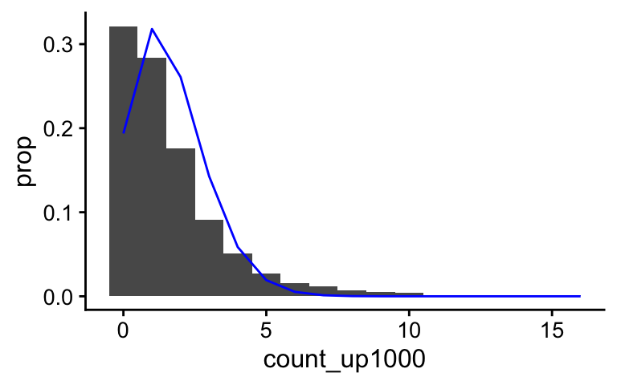

```r
CNYT_up1000_reducedmean <- CNYTCNYT_count_df %>%
    pull(count_up1000) %>%
    mean()

CNYT_up1000_reducedvar <- CNYTCNYT_count_df %>%
    pull(count_up1000) %>%
    var()

ggplot(data = CNYTCNYT_count_df, aes(x = count_up1000)) +
    geom_bar(width = 1, aes(y = ..prop..), stat = "count", group = 1) +
    geom_line(data = tibble(),
              aes(x = 0:20, y = dpois(0:20,lambda=CNYT_up1000_reducedmean)),
              colour = "blue") +
    scale_x_continuous(limits = c(-0.5,16), oob = scales::squish)
```

This count is overdispersed relative to a Poisson distribution, with mean 1.641343, variance 3.9394356.

## 100nt upstream

Results filtered to only the 100nt closest to the start codon.

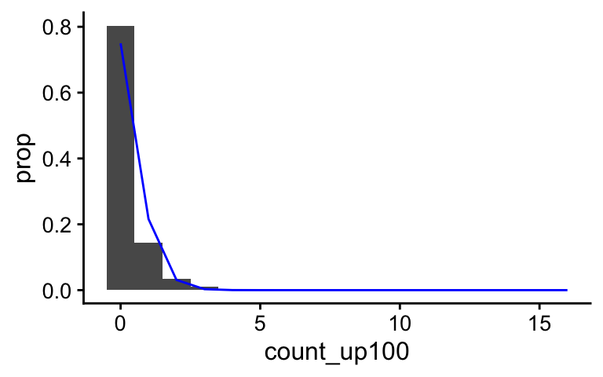

```r
CNYT_up100_reducedmean <- CNYTCNYT_count_df %>%
    pull(count_up100) %>%
    mean()

CNYT_up100_reducedvar <- CNYTCNYT_count_df %>%
    pull(count_up100) %>%
    var()

ggplot(data = CNYTCNYT_count_df, aes(x = count_up100)) +
    geom_bar(width = 1, aes(y = ..prop..), stat = "count", group = 1) +
    geom_line(data = tibble(),
              aes(x = 0:20, y = dpois(0:20,lambda=CNYT_up100_reducedmean)),
              colour = "blue") +
    scale_x_continuous(limits = c(-0.5,16), oob = scales::squish)
```

This count is also overdispersed relative to a Poisson distribution, with mean 0.2879468, variance 0.533756.

# Write list of genes for GO search, based on counts 100nt upstream

```r
id_file_CNYTCNYT1_up100 <- paste(here::here(),
                                 "motif_conservation",
                                 "results",
                                 "Ca_id_list_CNYTCNYT1_up100.txt",
                                 sep = "/")

CNYTCNYT_count_df %>%
    filter(count_up100 >= 1) %>%
    pull(id) %>%
    write_lines(file = id_file_CNYTCNYT1_up100)

id_file_CNYTCNYT2_up100 <- paste(here::here(),
                                 "motif_conservation",
                                 "results",
                                 "Ca_id_list_CNYTCNYT2_up100.txt",
                                 sep = "/")

CNYTCNYT_count_df %>%
    filter(count_up100 >= 2) %>%
    pull(id) %>%
    write_lines(file = id_file_CNYTCNYT2_up100)
```

Next, I did a GO term finder search of these genelists on [CGD](http://www.candidagenome.org/).

That found significantly enriched GO terms including cell wall (component) in genes with at least 2x CNYTCNYT motifs in the 100nt upstream, file `Ca_id_list_CNYTCNYT2_up100.txt`. Results are saved in the file `Ca_goFinderResult_28625_component_CGD_id_list_CNYTCNYT2_up100.txt`.